# lesson 5 practices

S.Omar

8/29/2020

```r
library(ggplot2)
di=data(diamonds)
str(diamonds)
```

```
## tibble [53,940 x 10] (S3: tbl_df/tbl/data.frame)
##  $ carat  : num [1:53940] 0.23 0.21 0.23 0.29 0.31 0.24 0.24 0.26 0.22 0.23 ...
##  $ cut    : Ord.factor w/ 5 levels "Fair"<"Good"<..: 5 4 2 4 2 3 3 3 1 3 ...
##  $ color  : Ord.factor w/ 7 levels "D"<"E"<"F"<"G"<..: 2 2 2 6 7 7 6 5 2 5 ...
##  $ clarity: Ord.factor w/ 8 levels "I1"<"SI2"<"SI1"<..: 2 3 5 4 2 6 7 3 4 5 ...
##  $ depth  : num [1:53940] 61.5 59.8 56.9 62.4 63.3 62.8 62.3 61.9 65.1 59.4 ...
##  $ table  : num [1:53940] 55 61 65 58 58 57 57 55 61 61 ...
##  $ price  : int [1:53940] 326 326 327 334 335 336 336 337 337 338 ...
##  $ x      : num [1:53940] 3.95 3.89 4.05 4.2 4.34 3.94 3.95 4.07 3.87 4 ...
##  $ y      : num [1:53940] 3.98 3.84 4.07 4.23 4.35 3.96 3.98 4.11 3.78 4.05 ...
##  $ z      : num [1:53940] 2.43 2.31 2.31 2.63 2.75 2.48 2.47 2.53 2.49 2.39 ...
```

```r
colnames(diamonds)
```

```
##  [1] "carat"   "cut"     "color"   "clarity" "depth"   "table"   "price"
##  [8] "x"       "y"       "z"
```

##Q1 Create a histogram of diamond prices. Facet the histogram by diamond color and use cut to color the histogram bars.

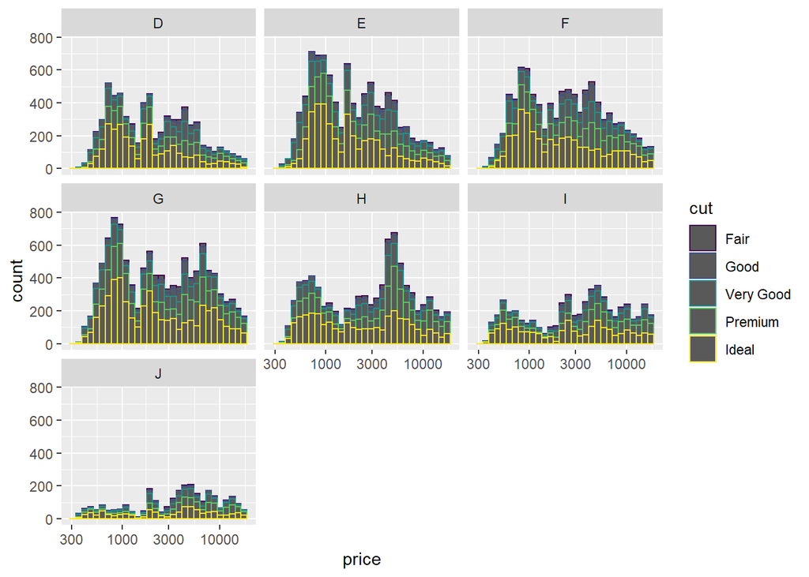

```r
ggplot(aes(price), data=diamonds)+facet_wrap(~color)+
  geom_histogram(aes(color=cut))+
  scale_x_log10()
```

##Q2: Create a scatterplot of diamond price vs. table and color the points by the cut of the diamond.

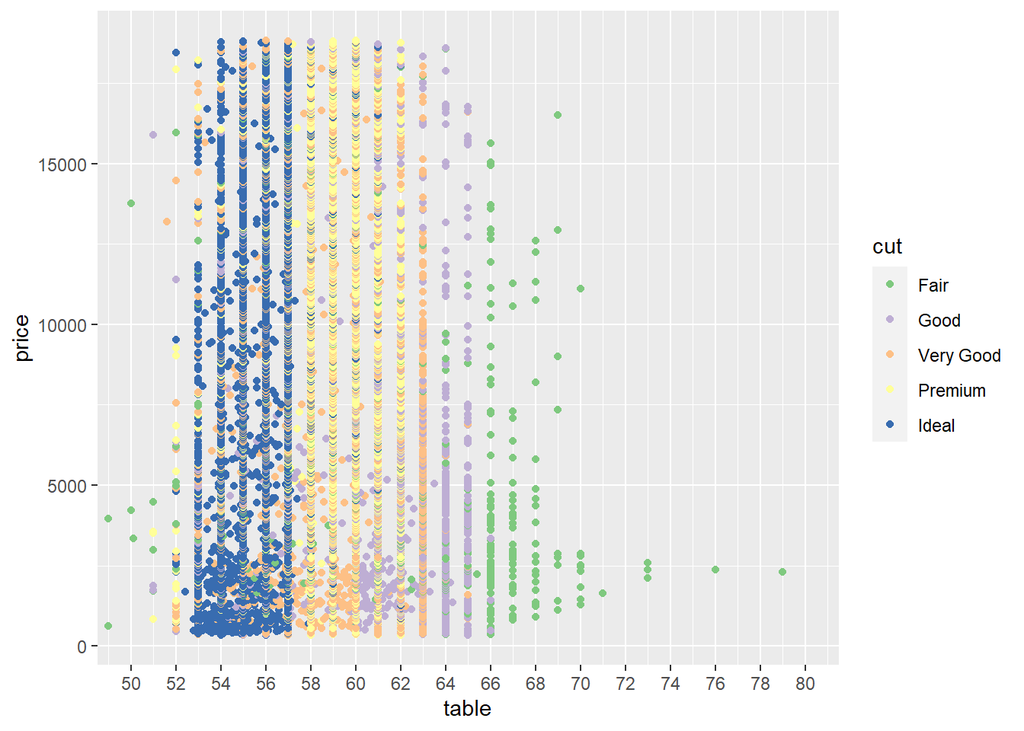

```r
ggplot(aes(table, price),data=diamonds)+geom_point(aes(color=cut))+
  scale_x_continuous(breaks = seq(40,80,2))+
  coord_cartesian(xlim = c(50,80))+
  scale_color_brewer(type = 'qual')
```

##Q3: from the plot i can say that the typical range for premium is: 58-62 and ideal cut: 53-57

##Q4: Create a scatterplot of diamond price vs. volume (x * y * z) and color the points by the clarity of diamonds. Use scale on the y-axis to take the log10 of price. You should also omit the top 1% of diamond volumes from the plot. a color palette of type ‘div’ was used to color the scatterplot using scale_color_brewer(type = ‘div’)

```r
diamonds =transform(diamonds, volume=x*y*z)

names(diamonds)
```

```
##  [1] "carat"   "cut"     "color"   "clarity" "depth"   "table"   "price"
##  [8] "x"       "y"       "z"       "volume"
```

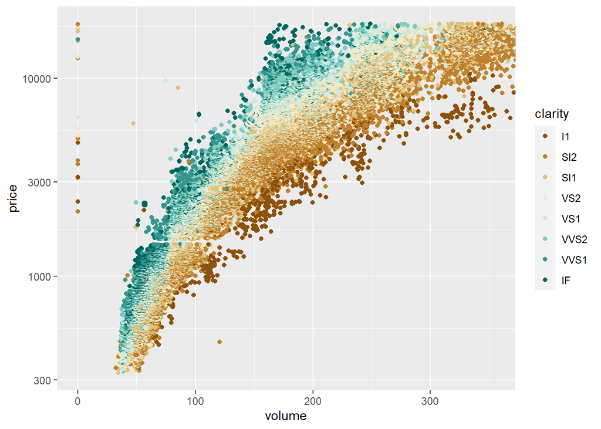

```r
ggplot(aes(volume, price), data=diamonds)+
  geom_point(aes(color=clarity))+
  scale_color_brewer(type='div')+ scale_y_log10() +
  coord_cartesian(xlim=c(0,quantile(diamonds$volume,0.99)))
```

##Q5: Proportion of Friendships Initiated

Notes: Many interesting variables are derived from two or more others. For example, we might wonder how much of a person’s network on a service like Facebook the user actively initiated. Two users with the same degree (or number of friends) might be very different if one initiated most of those connections on the service, while the other initiated very few. So it could be useful to consider this proportion of existing friendships that the user initiated. This might be a good predictor of how active a user is compared with their peers, or other traits, such as personality (i.e., is this person an extrovert?).

Your task is to create a new variable called ‘prop_initiated’ in the Pseudo-Facebook data set. The variable should contain the proportion of friendships that the user initiated.

```r
fb=read.delim("pseudo_facebook.tsv")

fb$prop_intiated= fb$friendships_initiated/fb$friend_count

print(names(fb))
```

```
##  [1] "userid"                "age"                   "dob_day"
##  [4] "dob_year"              "dob_month"             "gender"
##  [7] "tenure"                "friend_count"          "friendships_initiated"
## [10] "likes"                 "likes_received"        "mobile_likes"
## [13] "mobile_likes_received" "www_likes"             "www_likes_received"
## [16] "prop_intiated"
```

```r
print(summary(fb$prop_intiated))
```

```
##    Min. 1st Qu.  Median    Mean 3rd Qu.    Max.    NA's
##  0.0000  0.4524  0.6250  0.6078  0.7838  1.0000    1962
```

##Q6: prop_initiated vs. tenure Create a line graph of the median proportion of friendships initiated (‘prop_initiated’) vs.tenure and color the line segment by year_joined.bucket. Recall, we created year_joined.bucket in Lesson 5 by first creating year_joined from the variable tenure.Then, we used the cut function on year_joined to create four bins or cohorts of users.

(2004, 2009] (2009, 2011] (2011, 2012] (2012, 2014]

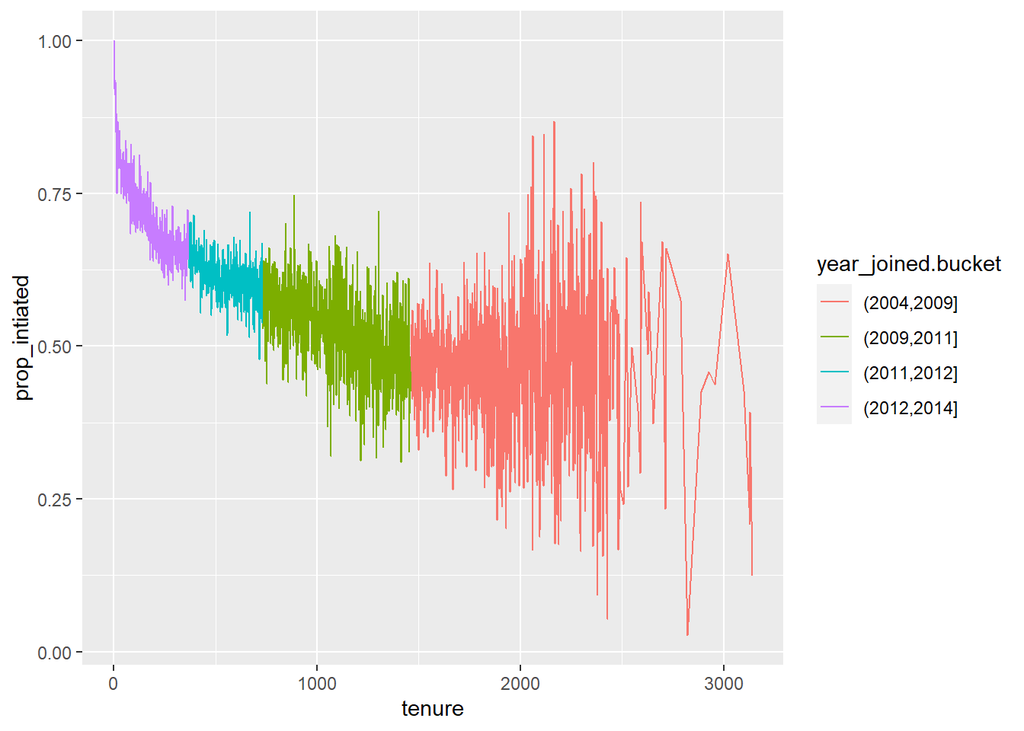

```r
fb$year_joined= floor(2014-fb$tenure/365)

fb$year_joined.bucket= cut(fb$year_joined, c(2004,2009,2011,2012,2014))

ggplot(aes(y=prop_intiated, x=tenure), data=fb)+
  geom_line(aes(color=year_joined.bucket), stat='summary', fun=median)
```

##Q7: Smoothing prop_initiated vs. tenure Notes: Smooth the last plot you created of of prop_initiated vs tenure colored by year_joined.bucket. You can use larger bins for tenure or add a smoother to the plot.

using large bins for smoothing:

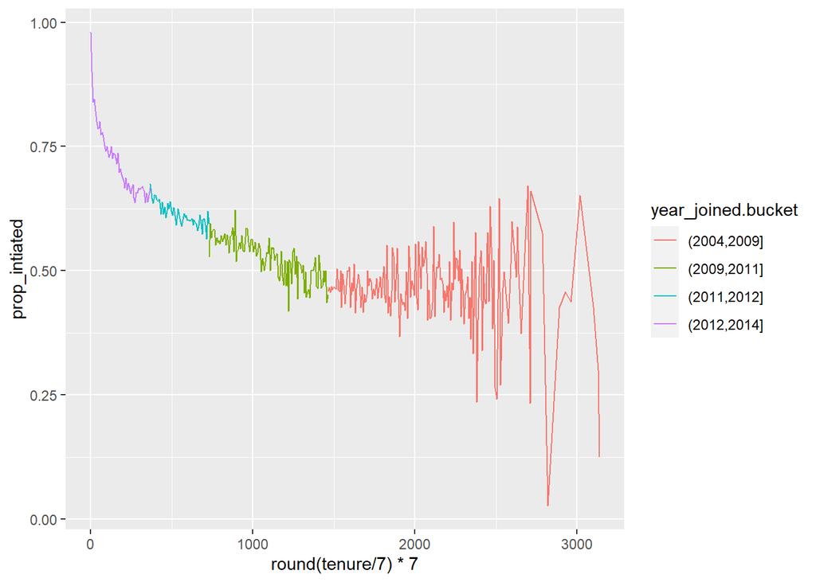

```r
ggplot(aes(y=prop_intiated, x=  round(tenure/7)*7 ),
       data=subset(fb, tenure>0))+
  geom_line(aes(color=year_joined.bucket), stat='summary', fun=median)
```

using smoother() for smoothing

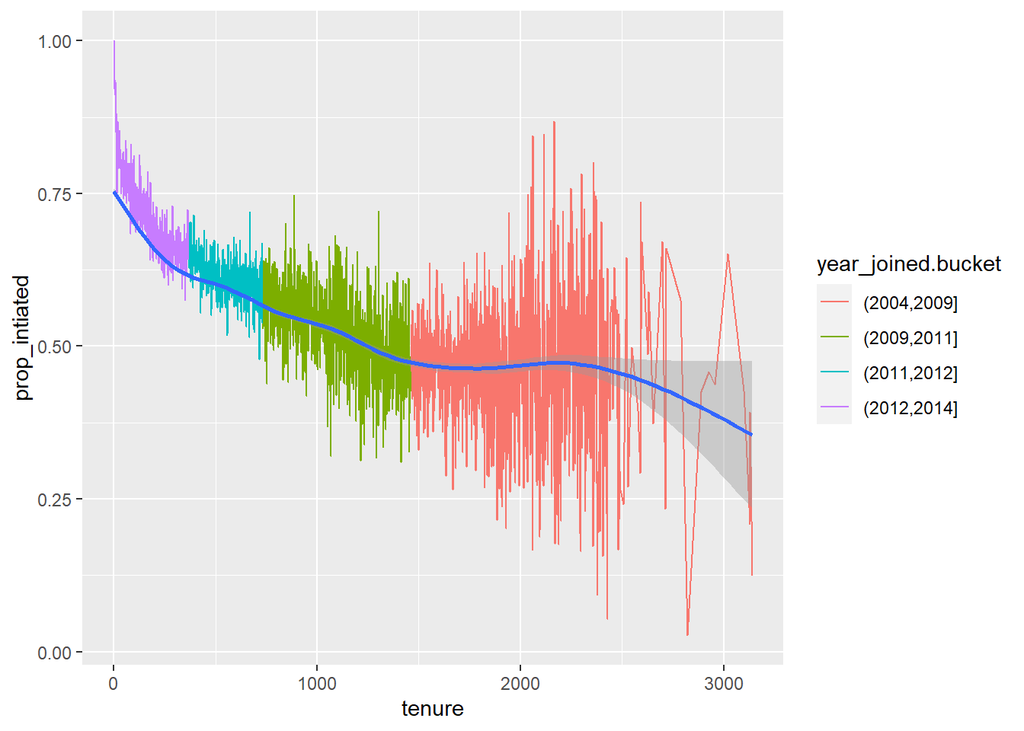

```r
ggplot(aes(y=prop_intiated, x=tenure), data=fb)+
  geom_line(aes(color=year_joined.bucket), stat='summary', fun=median)+
  geom_smooth()
```

##Q8:Greatest prop_initiated Group on average people who initiated after 2012 got the higher proportion.

```r
print(summary(fb$prop_intiated))
```

```
##    Min. 1st Qu.  Median    Mean 3rd Qu.    Max.    NA's
##  0.0000  0.4524  0.6250  0.6078  0.7838  1.0000    1962
```

```r
with(subset(fb,year_joined>2012 & year_joined <=2014), summary(age))
```

```
##    Min. 1st Qu.  Median    Mean 3rd Qu.    Max.
##   13.00   19.00   25.00   31.08   37.00  108.00
```

##Q10:Price/Carat Binned, Faceted, & Colored Notes: Create a scatter plot of the price/carat ratio of diamonds. The variable x should be assigned to cut. The points should be colored by diamond color, and the plot should be faceted by clarity.

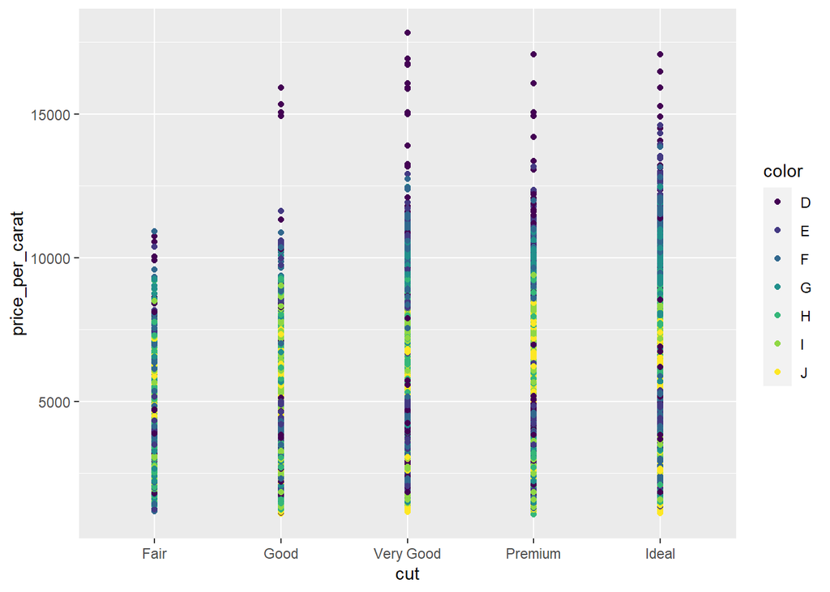

```r
diamonds$price_per_carat <- diamonds$price/ diamonds$carat

#plot a scater of price per cart vs cut
ggplot(aes(x = cut, y = price_per_carat), data = diamonds) +
  geom_point(aes(color=color))
```

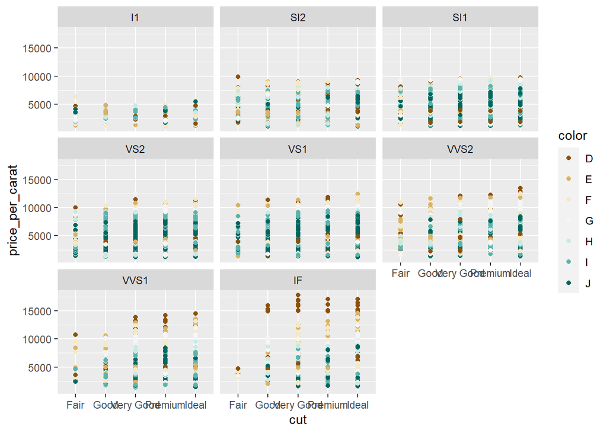

```r
diamonds$price_per_carat <- diamonds$price/ diamonds$carat

#plot a scater of price per cart vs cut
ggplot(aes(x = cut, y = price_per_carat), data = diamonds) +
  geom_point(aes(color=color)) +
  facet_wrap(~clarity)+
  scale_color_brewer(type = 'div')
```

##Q11: